[figure not shown]

```python
from IPython.display import Image
Image('title.png')
```

# Pravega '17 in Data

### A short introduction to Data Science in Python using Pravega '17 online registration data

#### Rohith KMS

# Some things you'll (hopefully) take away from this talk

- How to ask questions about data, and how to answer them.
- An idea about the general workflow of a Data Scientist
- The undisputable fact that Python is the coolest language on the planet
- An overview of the tools used for data analysis in python
- The power of Jupyter notebooks in Data Analysis.
- An idea of how to use Data Analysis in your own area of interest.

# The Libraries

- pandas
- numpy
- matplotlib
- basemap (For some geographical plots)

```python
import pandas as pd
import matplotlib.pyplot as plt
import seaborn as sns
from mpl_toolkits.basemap import Basemap
```

# Pandas

- The definitive python Data Science Library.
- Extremely powerful. Querying, Sorting and modfying data easy and efficient.
- Central data structures - DataFrame and Series
- Well-written pandas code is lovingly called 'Pandorable'

# Matplotlib

- Python's plotting library.
- Can do pretty much any imaginable kind of plot.
- As good as, if not better, than MATLAB plotting functionality.

# Seaborn

- Another plotting library built on matplotlib
- Basically matplotlib, but with better formatting, colors and ease of use

# Basemap

- A cool toolkit from matplotlib for plotting geographical data.

# The Data

### It's in the form of an excel file. Let's import it.

```python
df = pd.read_excel('Online Registrations Collegefever 2017.xlsx')
df.head(4)
```

|  | Name | Email | ContactNo | College / City Name | Ticket name | TCFRegistrationId | TicketPrice | RegisteredOn |
| --- | --- | --- | --- | --- | --- | --- | --- | --- |
| 0 | BISHWAJEET KUMAR SINGH | bksinghdhn@gmail.com | 9206821450 | BANGALORE | General Registration | 5582JE5 | 205 | Wed Nov 16 17:19:22 IST 2016 |
| 1 | N S Chiranjeevi | ns.chiranjeevi@students.iisertirupati.ac.in | 8792877680 | Indian Institute of Science Education and Rese... | General Registration | 3PPAHDT | 205 | Tue Nov 22 08:59:26 IST 2016 |
| 2 | N S Chiranjeevi | ns.chiranjeevi@students.iisertirupati.ac.in | 8792877680 | Indian Institute of Science Education and Rese... | Big Data | 3PPAHDT | 1500 | Tue Nov 22 08:59:26 IST 2016 |
| 3 | Shashank K M | shashank009.95@gmail.com | 9880711530 | St. Joseph College, Bangalore | Big Data | PSAXT4E | 1500 | Wed Nov 30 20:54:34 IST 2016 |

# Exploratory Data Analysis

### Understanding your data and asking questions

- How many registrations in total?
- What are the different workshops?
- How many colleges participated? How many cities?
- What are the ticket prices like?
- How did the number of registrations change as a function fo time?
- Do we have more participation from South India? If so, how much more?

```python
# Some answers.

print('We had ', df.shape[0], ' Registrations\n')
print('The different ticket names are: \n')

for thing in (df['Ticket name'].unique()):
    print(thing)
```

```
We had  1577  Registrations

The different ticket names are:

General Registration
Big Data
Cyber Forensics
Internet of Things
Android Controlled Robotics
Game Development using Virtual Reality
Automobile and IC Engine Design
Theatre Improv
Touch and Augmented Reality
Drone Photography
Quadcopter Workshop
Pravega Accommodation for 2 nights
Spray Paint Art
```

# Data cleaning

The least exciting, but necessary part in the workflow of a Data Scientist. Get rid of what you don't need. Make sure what you do need is in a nice format. For example,

- 'RegisteredOn' column: Convert string type to DateTime type
- The 'College Name/City column' requires some extensive text editing.
- City names need to be extracted and separated from College name.

```python
# Displaying the clean data skipping the messy code to avoid demotivation.

print('The cleaner ones: ')
df_lesser.head(3)
```

```
The cleaner ones:
```

| TCFRegistrationId | Name | College / City Name | Ticket name | TicketPrice | RegisteredOn |
| --- | --- | --- | --- | --- | --- |
| 5582JE5 | BISHWAJEET KUMAR SINGH | BANGALORE | General Registration | 205 | 2016-11-16 11:49:22+05:30 |
| 3PPAHDT | N S Chiranjeevi | Indian Institute of Science Education and Rese... | General Registration | 205 | 2016-11-22 03:29:26+05:30 |
| 3PPAHDT | N S Chiranjeevi | Indian Institute of Science Education and Rese... | Big Data | 1500 | 2016-11-22 03:29:26+05:30 |

```python
wksp_count
```

```
Internet of Things                        196
Big Data                                  194
Quadcopter Workshop                       152
Cyber Forensics                           146
Automobile and IC Engine Design           129
Android Controlled Robotics               124
Touch and Augmented Reality               108
Game Development using Virtual Reality     57
Theatre Improv                             27
Spray Paint Art                            12
Drone Photography                          11
Name: # of Registrations, dtype: int64
```

```python
locations.head(6)
```

| Ticket name | College | City |
| --- | --- | --- |
| General Registration | BANGALORE | Bangalore |
| General Registration | Indian Institute of Science Education and Rese... | Tirupati |
| Big Data | Indian Institute of Science Education and Rese... | Tirupati |
| Big Data | St. Joseph College, Bangalore | Bangalore |
| Big Data | St.Joseph College Bangalore | Bangalore |
| Big Data | St.Joseph's College,Bangalore | Bangalore |

```python
location_counts.head(6).rename(columns = {'College': 'Registrations'})
```

| City | Registrations |
| --- | --- |
| Anantapur | 82 |
| Bangalore | 301 |
| Bareilly | 1 |
| Belgaum | 2 |
| Bijapur | 7 |
| Chennai | 51 |

```python
wksp_location_counts.head(6)
```

| Ticket name City | Android Controlled Robotics | Automobile and IC Engine Design | Big Data | Cyber Forensics | Drone Photography | Game Development using Virtual Reality | General Registration | Internet of Things | Pravega Accommodation for 2 nights | Quadcopter Workshop | Spray Paint Art | Theatre Improv | Touch and Augmented Reality |
| --- | --- | --- | --- | --- | --- | --- | --- | --- | --- | --- | --- | --- | --- |
| Anantapur | 23.0 | 6.0 | 3.0 | 8.0 | 0.0 | 8.0 | 9.0 | 0.0 | 25.0 | 0.0 | 0.0 | 0.0 | 0.0 |
| Bangalore | 33.0 | 23.0 | 45.0 | 23.0 | 0.0 | 16.0 | 79.0 | 16.0 | 17.0 | 9.0 | 6.0 | 3.0 | 31.0 |
| Bareilly | 0.0 | 0.0 | 0.0 | 0.0 | 0.0 | 0.0 | 0.0 | 0.0 | 0.0 | 1.0 | 0.0 | 0.0 | 0.0 |
| Belgaum | 0.0 | 2.0 | 0.0 | 0.0 | 0.0 | 0.0 | 0.0 | 0.0 | 0.0 | 0.0 | 0.0 | 0.0 | 0.0 |
| Bijapur | 0.0 | 6.0 | 0.0 | 0.0 | 0.0 | 0.0 | 0.0 | 0.0 | 0.0 | 1.0 | 0.0 | 0.0 | 0.0 |
| Chennai | 3.0 | 0.0 | 14.0 | 7.0 | 0.0 | 1.0 | 7.0 | 1.0 | 18.0 | 0.0 | 0.0 | 0.0 | 0.0 |

```python
wksp_pmf.head(6)
```

| Ticket name City | Android Controlled Robotics | Automobile and IC Engine Design | Big Data | Cyber Forensics | Drone Photography | Game Development using Virtual Reality | Internet of Things | Quadcopter Workshop | Spray Paint Art | Theatre Improv | Touch and Augmented Reality |
| --- | --- | --- | --- | --- | --- | --- | --- | --- | --- | --- | --- |
| Anantapur | 0.479167 | 0.125000 | 0.062500 | 0.166667 | 0.0 | 0.166667 | 0.000000 | 0.000000 | 0.000000 | 0.000000 | 0.00000 |
| Bangalore | 0.160976 | 0.112195 | 0.219512 | 0.112195 | 0.0 | 0.078049 | 0.078049 | 0.043902 | 0.029268 | 0.014634 | 0.15122 |
| Bareilly | 0.000000 | 0.000000 | 0.000000 | 0.000000 | 0.0 | 0.000000 | 0.000000 | 1.000000 | 0.000000 | 0.000000 | 0.00000 |
| Belgaum | 0.000000 | 1.000000 | 0.000000 | 0.000000 | 0.0 | 0.000000 | 0.000000 | 0.000000 | 0.000000 | 0.000000 | 0.00000 |
| Bijapur | 0.000000 | 0.857143 | 0.000000 | 0.000000 | 0.0 | 0.000000 | 0.000000 | 0.142857 | 0.000000 | 0.000000 | 0.00000 |
| Chennai | 0.115385 | 0.000000 | 0.538462 | 0.269231 | 0.0 | 0.038462 | 0.038462 | 0.000000 | 0.000000 | 0.000000 | 0.00000 |

# Visualisation

The next important step in a Data Scientist's workflow is the visualisation.

- Visualising your data is an important step in Data Analysis. It helps us find patterns that we would otherwise have missed
- Data Visualisation is often the best means of conveying your results to an audience.
- Hence, Data visualisation is both an analytical and communicative tool.

Let's make some plots.

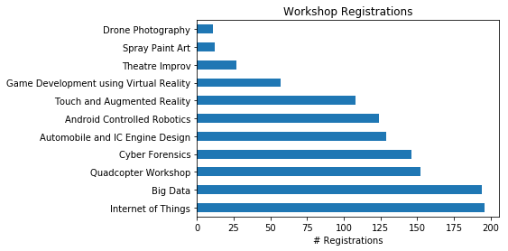

```python
%matplotlib inline
wksp_count.plot(kind = 'barh')

plt.xlabel('# Registrations')
plt.title('Workshop Registrations')
plt.show()
```

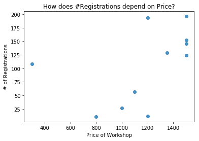

```python
prices = df_lesser.drop_duplicates('Ticket name').set_index('Ticket name')
prices = prices[['TicketPrice']]
prices = prices.drop(['General Registration', 'Pravega Accommodation for 2 nights'])

prices = prices.TicketPrice
prices.name = 'Price of Workshop'

sns.regplot(prices, wksp_count, fit_reg=False)
plt.title('How does #Registrations depend on Price?')
plt.show()
```

# Time Series Analysis

We have some nice Time Series Data. Let's use it.

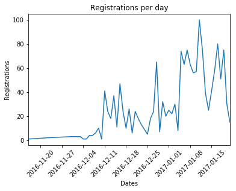

```python
df_dt = df_lesser.set_index('RegisteredOn')[['TicketPrice', 'Ticket name']]

df_dt['Ticket name'].groupby(df_dt.index.date).count().plot()
plt.tick_params('x', rotation = 45)

plt.xlabel('Dates')
plt.ylabel('Registrations')
plt.title('Registrations per day')

plt.show()
```

# Why are we doing this?

Now, prepare to get your minds blown. (Or not, depending if you dig this sort of thing.)

Let's just mark some important publicity events on this time-series.

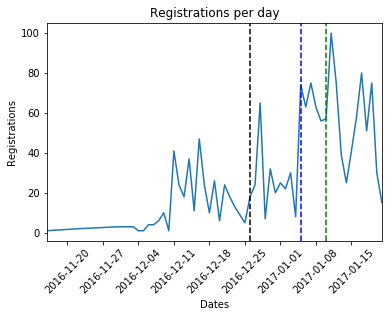

```python
df_dt = df_lesser.set_index('RegisteredOn')[['TicketPrice', 'Ticket name']]
df_dt['Ticket name'].groupby(df_dt.index.date).count().plot()
plt.tick_params('x', rotation = 45)
plt.xlabel('Dates')
plt.ylabel('Registrations')
plt.title('Registrations per day')
plt.axvline(pd.to_datetime('26 December 2016'), color = 'k', linestyle = '--') # Nucleya/Biswa Pravega post
plt.axvline(pd.to_datetime('5 January 2017'), color = 'b', linestyle = '--')   # Nucleya page post
plt.axvline(pd.to_datetime('10 January 2017'), color = 'g', linestyle = '--')  # Nucleya High Ape post

plt.show()
```

### and moving on

# Geographical Data Analysis

We've seen the temporal stuff. Time to focus on the other three dimensions.

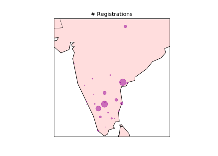

```python
%matplotlib notebook
m = Basemap(projection='mill',  # Miller projection
            resolution='c',     # Crude resolution
            llcrnrlat = 8, llcrnrlon = 65, urcrnrlat = 40, urcrnrlon = 100)
m.drawcountries()
m.drawmapboundary(color='#000000')
m.fillcontinents(color = '#FFDDDD', lake_color = '#FFFFFF')
m.drawcoastlines()
x,y = m(lons, lats)
m.scatter(x,y,marker = 'o', c = '#990099', alpha = 0.5, zorder = 5, s = sizes*2)
plt.title('# Registrations')
plt.show()
```

# Takeaway

### Data can be used to make better decisions

# Building models

Another step in the Data Scientist's workflow (Some argue that this is the key difference between data scientists and statisticians) is building models.

Statisticians tend to focus more on inferential models, and Data Scientists tend to focus on predictive models. [ Not my personal opinion. ]

# Types of predictive models

There are various kinds of predictive models one can try to build, and each of those is suited for a certain kind of problem. Some commononly used models are,

- Linear regression
- Artificial Neural Networks (ANN)
- Support vector means (SVM)
- K-Means clustering

You get the idea.

## Example model

# Recommending workshops based on location

Some workshops tend to be more popular than others in different cities. (We can expect significant differences across different colleges too, but let's keep things simple. (Read: I'm kinda lazy)

Let's take a look at how we go about building such a recommender.

[One that is not nearly as complex as some other recommenders out there]

```python
def recommend(city, n):

    print('\n\nWorkshop recommendations for ', city, '\n')

    if city in location_counts.index:
        for workshop in wksp_pmf.loc[city].sort_values(ascending = False).head(n).index:
            print(workshop)

    else:
        for i in (locations.T
                  .loc['Ticket name']
                  .value_counts()
                  .drop(['General Registration', 'Pravega Accommodation for 2 nights'])
                  .head(n)
                  .index):
            print(i)
```

```python
recommend('Salem', 3)       # In the list of cities
recommend('Vijayawada', 3)  # Not in the list of cities
```

```
Workshop recommendations for  Salem

Game Development using Virtual Reality
Touch and Augmented Reality
Theatre Improv


Workshop recommendations for  Vijayawada

Internet of Things
Big Data
Quadcopter Workshop
```

```python
Image('xkcd_extrapolation.png')
```

[output not shown]